# Day 4 - Graphics

September 19, 2016

# Overview

- Effective visualizations
- Grammar of graphics
- ggplot practical

# Effective visualizations

- Why do we plot data?
- What makes a good plot?

# Plot types

### Scatter plot

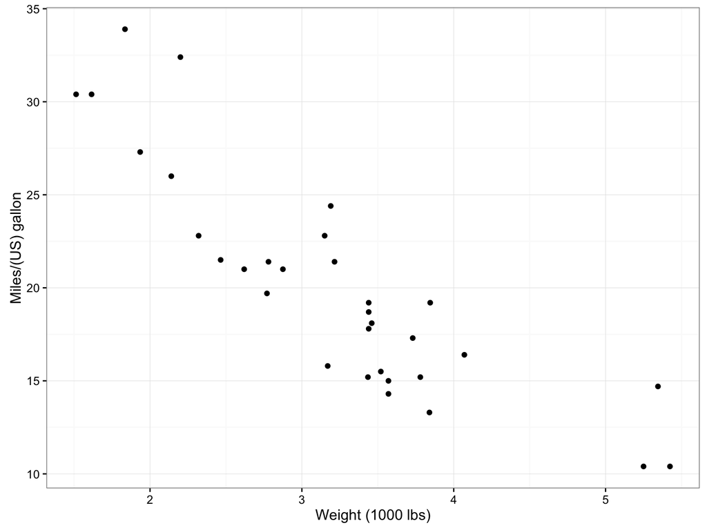

### Bar chart

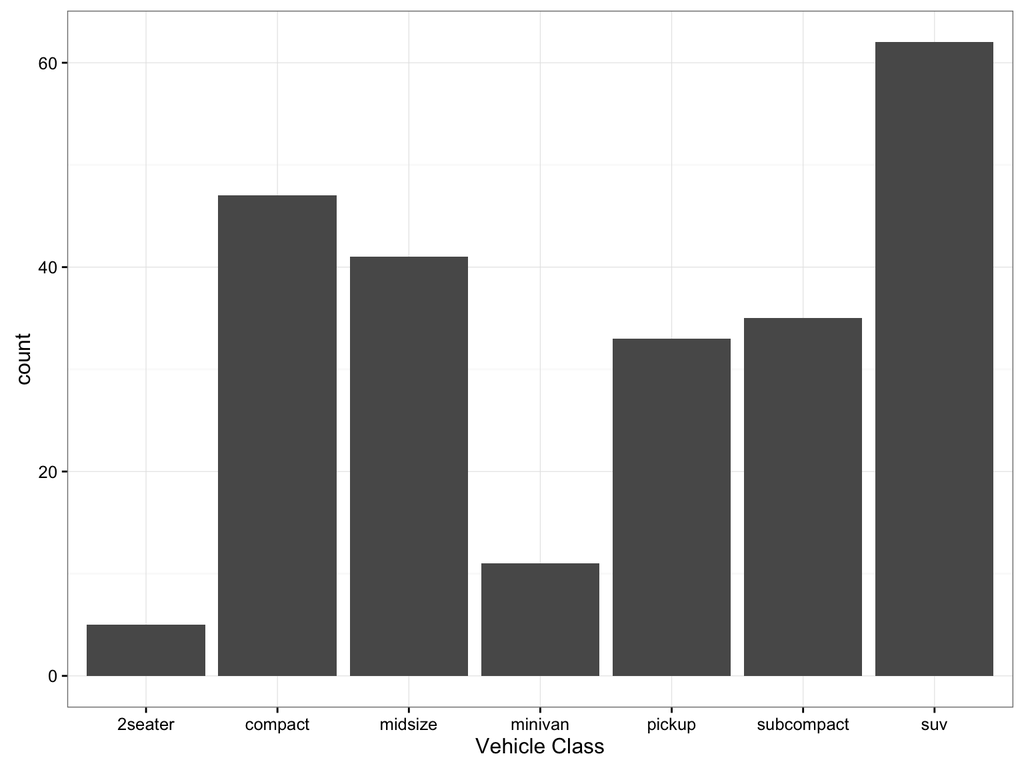

### Histogram

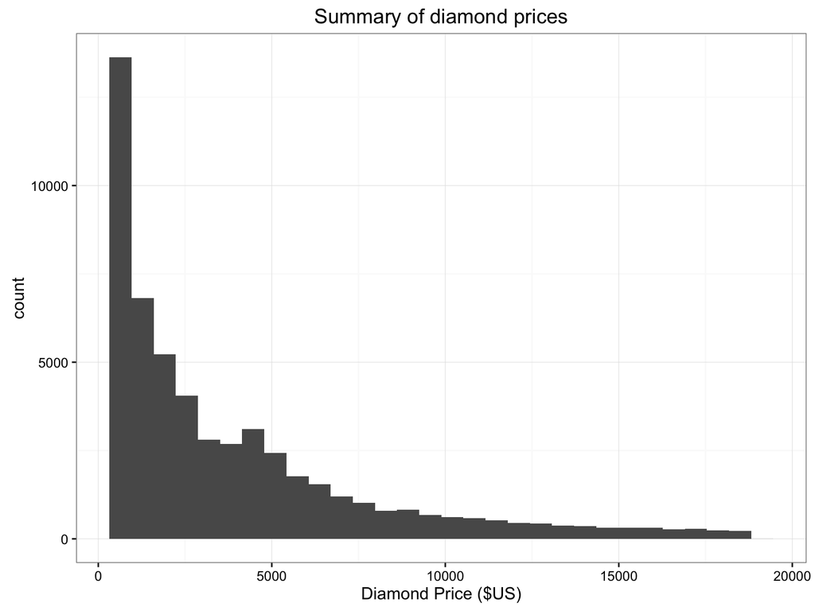

### Boxplot

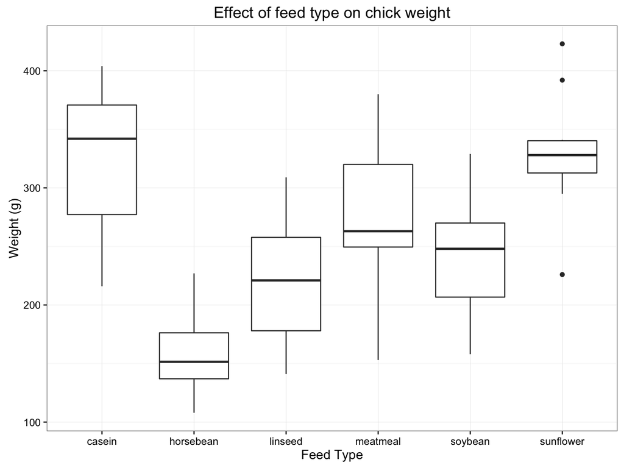

### Line plots

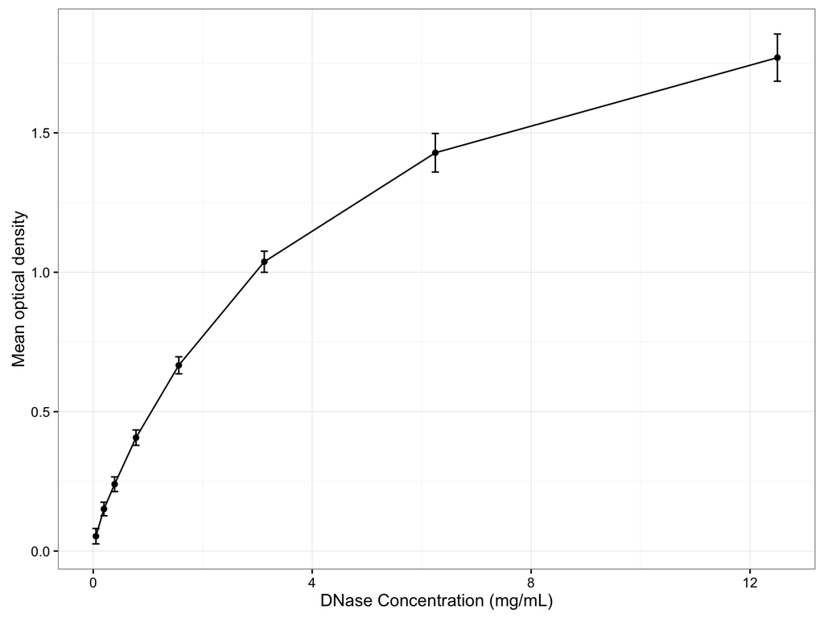

### Time series

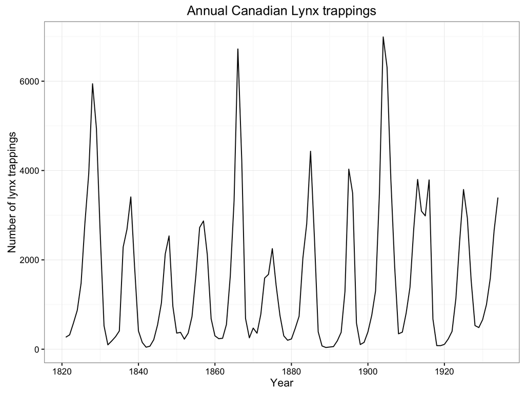

### Heatmap

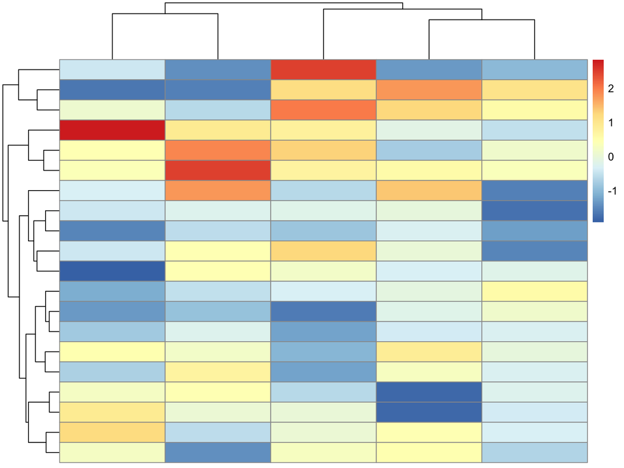

# Good Visualizations

- tell a story
- are easy to understand
- are simple
- contain all the information need to interpret the plot

# Tips

- Think about what you are trying to convey
- Don’t include a figure because it looks “cool”
- Ask yourself if the figure is as simple as it could be
- Use colours but think about color blindness
- Don’t use more than 10 - 12 colours to distinguish groups
- Sometimes a table is better
- Don’t use pie charts
- Don’t use stacked bar charts
- Use facet panels to reduce clutter
- Avoid overplotting

See the book, *The Visual Display of Quantitative Information* by Edward Tufte for more information.

# Grammar of Graphics

- A vocabulary to descibe how to build a statistical graphic.
- Plot elements are well defined and by combining them using a set of rules we can create a wide variety of complex statistical graphics.
- We build graphics like we build sentences and paragraphs.

# More info

ggplot2 [book](https://www.amazon.ca/ggplot2-Elegant-Graphics-Data-Analysis/dp/331924275X/ref=sr_1_1?ie=UTF8&qid=1474233790&sr=8-1&keywords=elegant+graphics+for+data+analysis)

[Cookbook for R](http://www.cookbook-r.com/Graphs/)

ggplot2 [documentation](http://docs.ggplot2.org/current/)